# Activity 8: FluSight-Compliant Final Forecast

This activity turns the best-performing forecast from the expanded modeling work into a FluSight-ready product. The workflow is deliberately conservative: it preserves the Activity 3 reference dates, horizons, target definition, and quantile format; compares ARIMA, Activity 5, Activity 7 XGBoost, Activity 7 XGBoost with leading indicators, ARIMAX, calibrated, blended, horizon-specific, phase-calibrated, and reconciled candidates with held-out weighted interval score (WIS); and validates the final submission files before they are written.

```r
knitr::opts_chunk$set(message = FALSE, warning = TRUE, fig.width = 10, fig.height = 6)

find_project_dir <- function(start_dir = getwd()) {
  candidates <- unique(c(
    start_dir,
    file.path(start_dir, "USE-ME", "carolmoreira"),
    file.path(start_dir, ".."),
    file.path(start_dir, "..", ".."),
    file.path(start_dir, "..", "..", "..")
  ))
  candidates <- normalizePath(candidates, mustWork = FALSE)
  candidates <- candidates[file.exists(file.path(candidates, "output/scripts/08_flusight.R"))]
  if (!length(candidates)) stop("Could not locate USE-ME/carolmoreira.")
  candidates[1]
}

project_dir <- find_project_dir()
knitr::opts_knit$set(root.dir = project_dir)
if (!isTRUE(getOption("knitr.in.progress"))) setwd(project_dir)
cat("Working directory:", project_dir, "\n")
```

```
## Working directory: /Users/carolmoreira/sismid/SISMID-2026-HumanAI/USE-ME/carolmoreira
```

## 1 Run The Workflow

The script below is the reproducible source of truth for Activity 8. It rebuilds the ARIMAX candidates, blends them with the Activity 5 ensemble and original ARIMA forecast, selects the best model by held-out mean WIS, and writes the final FluSight files.

```r
source("output/scripts/08_flusight.R")
```

```
## Season Start Week: 2025-09-28
## Season End Week: 2026-05-17
```

```
## Activity 8 FluSight workflow complete.
## External regressors: NWSS WVAL lag 6 weeks; NSSP smoothed influenza lag 6 weeks.
## Final FluSight model: Horizon-specific: h1 XGBoost blend, h2-h3 XGBoost
## Final forecast: output/data/08_flusight/flusight_final_forecasts.csv
## Submission files: output/data/08_flusight/final_flusight_submission
## [val] quantiles non-decreasing: OK
## [val] all quantile levels present: OK
## [val] target dates correct: OK
## [diag] intervals widen with horizon: not required for selected direct/hybrid model
## [val] one file per reference date: OK
## # A tibble: 36 x 8
##    model      horizon n_forecasts   mae  rmse mean_wis coverage_95 mean_width_95
##    <chr>        <int>       <int> <dbl> <dbl>    <dbl>       <dbl>         <dbl>
##  1 ARIMAX: s~       1          34 2074. 3074.    1474.       0.912        10432.
##  2 Activity ~       1          34 1859. 3446.    1494.       0.882         6244.
##  3 Activity ~       1          34 2605. 5092.    1650.       0.882        13476.
##  4 Activity ~       1          34 2600. 4919.    1763.       0.912        20658.
##  5 Blend: 50~       1          34 1868. 3167.    1438.       0.882         8341.
##  6 Blend: 50~       1          34 1980. 3648.    1333.       0.941        10909.
##  7 Blend: 85~       1          34 2542. 4942.    1621.       0.941        14554.
##  8 Calibrate~       1          34 2074. 3074.    1484.       0.912        12014.
##  9 Calibrate~       1          34 1868. 3167.    1492.       0.912        12155.
## 10 Horizon-s~       1          34 1980. 3648.    1333.       0.941        10909.
## # i 26 more rows
```

## 2 Load Outputs

```r
required <- c("readr", "dplyr", "tidyr", "ggplot2", "knitr")
missing <- required[!vapply(required, requireNamespace, logical(1), quietly = TRUE)]
if (length(missing)) stop("Required R package(s) not installed: ", paste(missing, collapse = ", "))

library(readr)
library(dplyr)
library(tidyr)
library(ggplot2)
library(knitr)
```

```r
truth_csv <- "output/data/01_cleaning/cleaned_flu_admissions.csv"
inventory_csv <- "output/data/08_flusight/upstream_data_stream_inventory.csv"
spec_csv <- "output/data/08_flusight/arimax_specification.csv"
comparison_csv <- "output/data/08_flusight/arimax_model_comparison_by_horizon.csv"
ranking_csv <- "output/data/08_flusight/flusight_model_ranking.csv"
final_forecast_csv <- "output/data/08_flusight/flusight_final_forecasts.csv"
submission_manifest_csv <- "output/data/08_flusight/final_flusight_submission_manifest.csv"
compliance_audit_csv <- "output/data/08_flusight/flusight_compliance_audit.csv"
reconciliation_audit_csv <- "output/data/08_flusight/flusight_reconciliation_audit.csv"

stream_png <- "output/figures/08_flusight/surveillance_streams_overview.png"
lag_png <- "output/figures/08_flusight/lagged_covariate_relationships.png"
component_png <- "output/figures/08_flusight/blend_vs_component_medians.png"
ranking_png <- "output/figures/08_flusight/flusight_model_ranking.png"
final_forecast_png <- "output/figures/08_flusight/flusight_final_forecast_vs_observed.png"
metric_png <- "output/figures/08_flusight/arimax_metric_comparison.png"
calibration_png <- "output/figures/08_flusight/rolling_interval_calibration_multipliers.png"

expected <- c(truth_csv, inventory_csv, spec_csv, comparison_csv, ranking_csv,
              final_forecast_csv, submission_manifest_csv, compliance_audit_csv,
              reconciliation_audit_csv,
              stream_png, lag_png, component_png, ranking_png, final_forecast_png,
              metric_png, calibration_png)
if (!all(file.exists(expected))) {
  stop("Missing Activity 8 output(s): ", paste(expected[!file.exists(expected)], collapse = ", "))
}
```

## 3 Inputs And Leading Signals

The final candidate set uses the cleaned national influenza hospitalization target, the Activity 7 XGBoost forecasts, and two upstream national surveillance streams: NWSS wastewater viral activity level and NSSP smoothed influenza emergency-department visit percent. The external surveillance signals are lagged six weeks before ARIMAX and XGBoost-leading modeling, which makes them available before every 1-, 2-, and 3-week-ahead target date.

```r
read_csv(inventory_csv, show_col_types = FALSE) %>%
  kable(caption = "Input stream inventory and model role.")
```

Input stream inventory and model role.

| stream | source_file | rows | date_start | date_end | model_use |
| --- | --- | --- | --- | --- | --- |
| Cleaned HRD admissions | output/data/01_cleaning/cleaned_flu_admissions.csv | 307 | 2020-08-08 | 2026-06-20 | Forecast target |
| NWSS WVAL | data/NWSSWVALNational.csv | 104 | 2024-07-13 | 2026-07-04 | External regressor, lagged 6 weeks |
| NSSP influenza ED visits | data/NSSPNational.csv | 197 | 2022-10-01 | 2026-07-04 | External regressor, lagged 6 weeks |
| Historical truth iterations | data/time-series-all-historical-iterations.csv | 6805 | 2022-02-05 | 2026-06-06 | Inventory only; real-time truth archive, not an exogenous predictor |

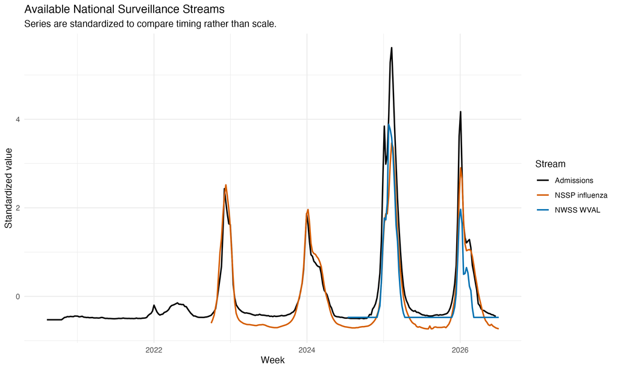

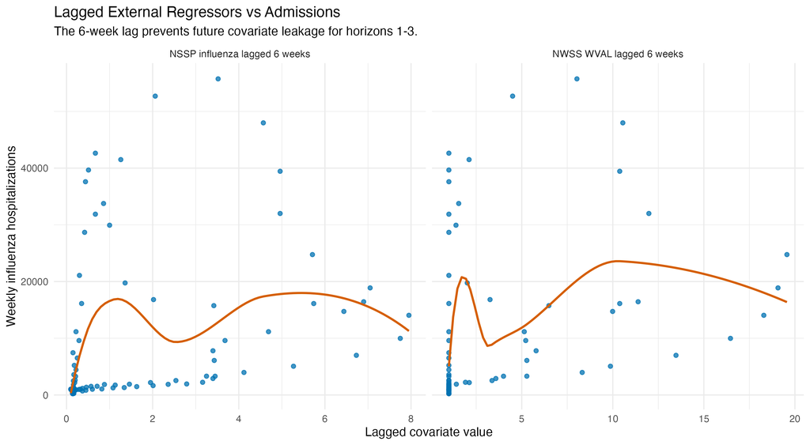

## 4 Model Specification

The central ARIMAX candidate uses lagged NWSS WVAL, lagged NSSP influenza ED visits, deterministic MMWR timing features, lagged current-season cumulative admissions, and a lagged post-peak-decline flag. The Activity 7 XGBoost candidate uses admissions lags and seasonal harmonics, and the XGBoost-leading candidate adds lagged WVAL/NSSP. The post-peak ARIMAX feature is computed from the peak observed so far, then lagged, so it does not use the eventual full-season peak.

```r
read_csv(spec_csv, show_col_types = FALSE) %>%
  kable(caption = "ARIMAX specification used inside the final candidate set.")
```

ARIMAX specification used inside the final candidate set.

| model | regressors | regressor_lag_weeks | leakage_rule | reference_dates | quantile_levels |
| --- | --- | --- | --- | --- | --- |
| ARIMAX: surveillance + seasonal | NWSS National WVAL; NSSP smoothed influenza ED visit percentage; MMWR week sine/cosine; weeks since season start; lagged current-season cumulative admissions; lagged post-peak decline indicator | 6 | For target week t, use covariates from t - 42 days; horizon 3 uses covariates no later than 21 days before the reference date. | 34 | 23 |

## 5 Candidate Ranking

The selected production forecast is the lowest mean WIS candidate across all scored reference dates and horizons. WIS is the primary ranking metric because it rewards both sharpness and calibration. The candidate set now includes a horizon-specific model that uses the XGBoost-weighted blend for horizon 1 and raw Activity 7 XGBoost for horizons 2 and 3, a low-weight raw/leading XGBoost ensemble, and a phase-aware interval calibration candidate. MAE and RMSE are shown as supporting central-forecast diagnostics, while coverage and interval width describe uncertainty behavior.

```r
ranking <- read_csv(ranking_csv, show_col_types = FALSE)
best_model <- ranking$model[1]
ranking %>%
  mutate(across(c(mean_wis, mae, rmse, coverage_95, mean_width_95), round, 3)) %>%
  kable(caption = "Overall model ranking. Lower WIS is better.")
```

Overall model ranking. Lower WIS is better.

| model | scored_forecasts | mean_wis | mae | rmse | coverage_95 | mean_width_95 |
| --- | --- | --- | --- | --- | --- | --- |
| Horizon-specific: h1 XGBoost blend, h2-h3 XGBoost | 102 | 2098.761 | 3126.186 | 6131.007 | 0.902 | 15452.96 |
| Phase-calibrated horizon-specific | 102 | 2139.735 | 3126.186 | 6131.007 | 0.892 | 12130.06 |
| Blend: 85% XGBoost, 15% XGBoost-leading | 102 | 2193.238 | 3353.069 | 6359.673 | 0.922 | 17588.45 |
| Activity 7 XGBoost | 102 | 2204.249 | 3334.422 | 6464.952 | 0.882 | 16308.90 |
| Blend: 50% XGBoost, 25% ARIMAX, 15% ensemble, 10% ARIMA | 102 | 2388.877 | 3515.873 | 6367.906 | 0.922 | 15780.68 |
| Activity 7 XGBoost + leading indicators | 102 | 2734.697 | 4673.980 | 8273.109 | 0.931 | 24839.09 |
| Blend: 50% ARIMAX, 25% ensemble, 25% ARIMA | 102 | 3104.474 | 4116.961 | 7320.937 | 0.873 | 15254.14 |
| ARIMAX: surveillance + seasonal | 102 | 3199.393 | 4714.745 | 7072.458 | 0.892 | 18846.90 |
| Calibrated blend | 102 | 3209.510 | 4116.961 | 7320.937 | 0.892 | 22649.97 |
| Calibrated ARIMAX | 102 | 3215.370 | 4714.745 | 7072.458 | 0.912 | 22384.03 |
| Activity 5 ensemble | 102 | 3272.015 | 4098.559 | 7986.329 | 0.863 | 11643.84 |
| Original ARIMA | 102 | 3331.272 | 4154.706 | 8233.335 | 0.863 | 11678.82 |

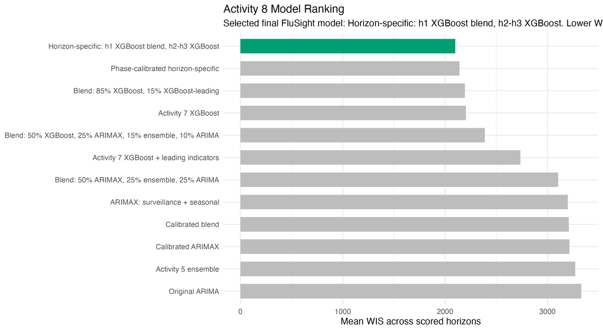

The final model selected by held-out mean WIS is:

```r
cat(best_model)
```

```
## Horizon-specific: h1 XGBoost blend, h2-h3 XGBoost
```

## 6 Horizon-Level Performance

```r
comparison <- read_csv(comparison_csv, show_col_types = FALSE)
comparison %>%
  mutate(across(c(mae, rmse, mean_wis, coverage_95, mean_width_95), round, 3)) %>%
  arrange(horizon, mean_wis) %>%
  kable(caption = "Model comparison by forecast horizon.")
```

Model comparison by forecast horizon.

| model | horizon | n_forecasts | mae | rmse | mean_wis | coverage_95 | mean_width_95 |
| --- | --- | --- | --- | --- | --- | --- | --- |
| Blend: 50% XGBoost, 25% ARIMAX, 15% ensemble, 10% ARIMA | 1 | 34 | 1980.235 | 3648.463 | 1333.178 | 0.941 | 10908.618 |
| Horizon-specific: h1 XGBoost blend, h2-h3 XGBoost | 1 | 34 | 1980.235 | 3648.463 | 1333.178 | 0.941 | 10908.618 |
| Phase-calibrated horizon-specific | 1 | 34 | 1980.235 | 3648.463 | 1341.437 | 0.941 | 8206.618 |
| Blend: 50% ARIMAX, 25% ensemble, 25% ARIMA | 1 | 34 | 1868.029 | 3166.703 | 1437.977 | 0.882 | 8341.206 |
| ARIMAX: surveillance + seasonal | 1 | 34 | 2074.324 | 3074.106 | 1473.756 | 0.912 | 10431.912 |
| Calibrated ARIMAX | 1 | 34 | 2074.324 | 3074.106 | 1483.695 | 0.912 | 12014.235 |
| Calibrated blend | 1 | 34 | 1868.029 | 3166.703 | 1492.304 | 0.912 | 12155.059 |
| Activity 5 ensemble | 1 | 34 | 1859.176 | 3446.426 | 1494.176 | 0.882 | 6243.500 |
| Original ARIMA | 1 | 34 | 1954.176 | 3404.723 | 1547.448 | 0.882 | 6257.294 |
| Blend: 85% XGBoost, 15% XGBoost-leading | 1 | 34 | 2541.529 | 4941.960 | 1620.756 | 0.941 | 14553.853 |
| Activity 7 XGBoost | 1 | 34 | 2604.941 | 5092.188 | 1649.641 | 0.882 | 13476.441 |
| Activity 7 XGBoost + leading indicators | 1 | 34 | 2599.735 | 4918.741 | 1762.556 | 0.912 | 20657.676 |
| Blend: 85% XGBoost, 15% XGBoost-leading | 2 | 34 | 3360.441 | 6652.826 | 2283.857 | 0.912 | 18315.971 |
| Activity 7 XGBoost | 2 | 34 | 3374.029 | 6723.131 | 2296.544 | 0.882 | 17240.382 |
| Horizon-specific: h1 XGBoost blend, h2-h3 XGBoost | 2 | 34 | 3374.029 | 6723.131 | 2296.544 | 0.882 | 17240.382 |
| Phase-calibrated horizon-specific | 2 | 34 | 3374.029 | 6723.131 | 2347.977 | 0.853 | 13441.324 |
| Blend: 50% XGBoost, 25% ARIMAX, 15% ensemble, 10% ARIMA | 2 | 34 | 3661.824 | 6349.222 | 2492.981 | 0.912 | 16579.088 |
| Activity 7 XGBoost + leading indicators | 2 | 34 | 5149.941 | 8815.174 | 3004.309 | 0.941 | 24411.765 |
| Blend: 50% ARIMAX, 25% ensemble, 25% ARIMA | 2 | 34 | 4386.912 | 7161.579 | 3294.304 | 0.853 | 15919.618 |
| ARIMAX: surveillance + seasonal | 2 | 34 | 4944.000 | 6928.965 | 3363.945 | 0.882 | 19760.500 |
| Calibrated ARIMAX | 2 | 34 | 4944.000 | 6928.965 | 3373.182 | 0.912 | 23327.647 |
| Calibrated blend | 2 | 34 | 4386.912 | 7161.579 | 3386.404 | 0.853 | 23549.059 |
| Activity 5 ensemble | 2 | 34 | 4364.676 | 7732.303 | 3484.610 | 0.853 | 12060.765 |
| Original ARIMA | 2 | 34 | 4407.706 | 7925.581 | 3531.953 | 0.853 | 12096.559 |
| Activity 7 XGBoost | 3 | 34 | 4024.294 | 7365.864 | 2666.561 | 0.882 | 18209.882 |
| Horizon-specific: h1 XGBoost blend, h2-h3 XGBoost | 3 | 34 | 4024.294 | 7365.864 | 2666.561 | 0.882 | 18209.882 |
| Blend: 85% XGBoost, 15% XGBoost-leading | 3 | 34 | 4157.235 | 7256.256 | 2675.101 | 0.912 | 19895.529 |
| Phase-calibrated horizon-specific | 3 | 34 | 4024.294 | 7365.864 | 2729.792 | 0.882 | 14742.235 |
| Blend: 50% XGBoost, 25% ARIMAX, 15% ensemble, 10% ARIMA | 3 | 34 | 4905.559 | 8247.836 | 3340.472 | 0.912 | 19854.324 |
| Activity 7 XGBoost + leading indicators | 3 | 34 | 6272.265 | 10170.137 | 3437.227 | 0.941 | 29447.824 |
| Blend: 50% ARIMAX, 25% ensemble, 25% ARIMA | 3 | 34 | 6095.941 | 9973.572 | 4581.142 | 0.882 | 21501.588 |
| Calibrated blend | 3 | 34 | 6095.941 | 9973.572 | 4749.822 | 0.912 | 32245.794 |
| ARIMAX: surveillance + seasonal | 3 | 34 | 7125.912 | 9622.802 | 4760.477 | 0.882 | 26348.294 |
| Calibrated ARIMAX | 3 | 34 | 7125.912 | 9622.802 | 4789.235 | 0.912 | 31810.206 |
| Activity 5 ensemble | 3 | 34 | 6071.824 | 10939.742 | 4837.259 | 0.853 | 16627.265 |
| Original ARIMA | 3 | 34 | 6102.235 | 11355.899 | 4914.413 | 0.853 | 16682.618 |

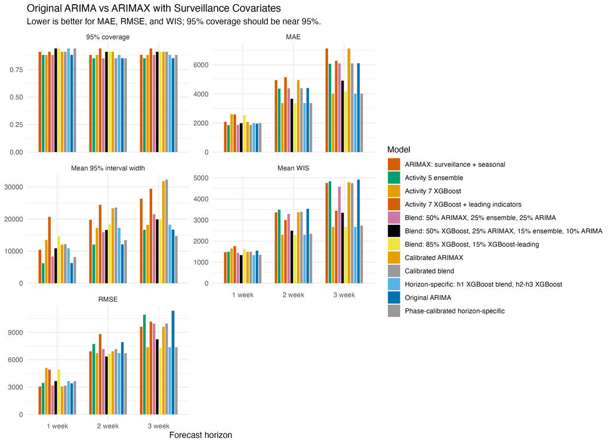

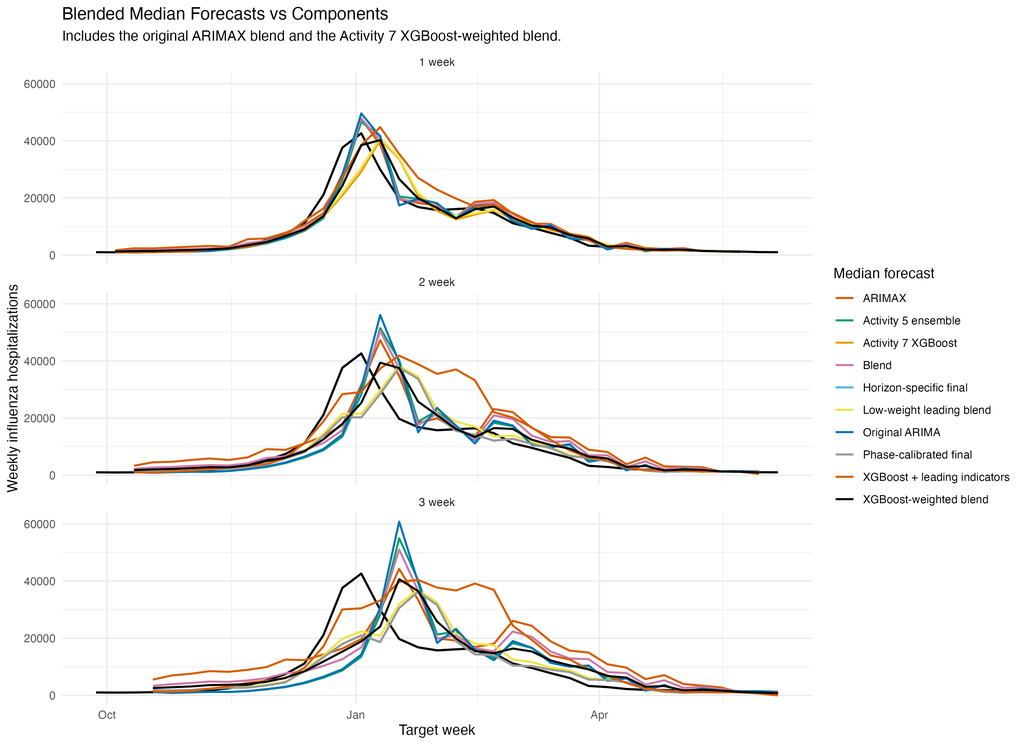

## 7 Interval Calibration

Rolling interval calibration was evaluated as an explicit candidate rather than assumed to be better. It improved coverage for some horizons but increased interval width substantially. After Activity 7 was added, XGBoost-style direct quantile forecasts were also allowed into the final ranking; for those models, horizon-wise interval widening is reported diagnostically rather than treated as a hard stop because direct per-horizon quantile models are not guaranteed to widen monotonically.

The final refinement also adds phase-aware calibration. It estimates interval multipliers from prior realized errors with the same horizon and epidemic phase when enough historical examples are available, falling back to horizon-only history when the phase-specific sample is too small.

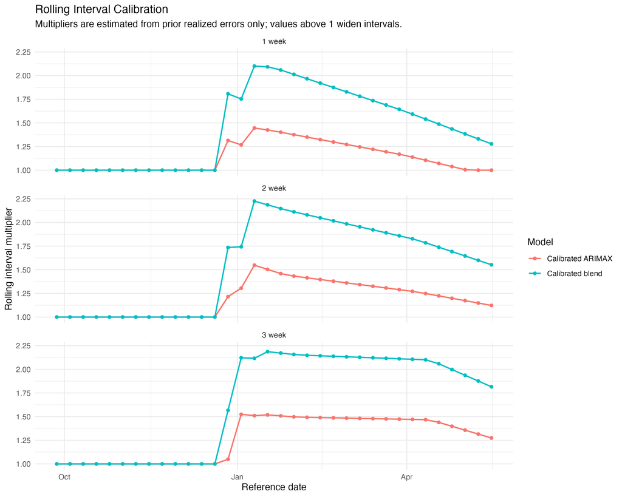

## 8 Final Forecast

The final forecast keeps the required FluSight long format: one row per reference date, target, horizon, location, output type, quantile level, and forecast value.

```r
final_fc <- read_csv(final_forecast_csv, show_col_types = FALSE)
final_fc %>%
  arrange(reference_date, horizon, output_type_id) %>%
  head(12) %>%
  kable(caption = "Preview of the final FluSight forecast file.")
```

Preview of the final FluSight forecast file.

| reference_date | target | horizon | target_end_date | location | output_type | output_type_id | value |
| --- | --- | --- | --- | --- | --- | --- | --- |
| 2025-09-27 | wk inc flu hosp | 1 | 2025-10-04 | US | quantile | 0.010 | 164 |
| 2025-09-27 | wk inc flu hosp | 1 | 2025-10-04 | US | quantile | 0.025 | 346 |
| 2025-09-27 | wk inc flu hosp | 1 | 2025-10-04 | US | quantile | 0.050 | 440 |
| 2025-09-27 | wk inc flu hosp | 1 | 2025-10-04 | US | quantile | 0.100 | 460 |
| 2025-09-27 | wk inc flu hosp | 1 | 2025-10-04 | US | quantile | 0.150 | 520 |
| 2025-09-27 | wk inc flu hosp | 1 | 2025-10-04 | US | quantile | 0.200 | 536 |
| 2025-09-27 | wk inc flu hosp | 1 | 2025-10-04 | US | quantile | 0.250 | 544 |
| 2025-09-27 | wk inc flu hosp | 1 | 2025-10-04 | US | quantile | 0.300 | 634 |
| 2025-09-27 | wk inc flu hosp | 1 | 2025-10-04 | US | quantile | 0.350 | 800 |
| 2025-09-27 | wk inc flu hosp | 1 | 2025-10-04 | US | quantile | 0.400 | 961 |
| 2025-09-27 | wk inc flu hosp | 1 | 2025-10-04 | US | quantile | 0.450 | 1117 |
| 2025-09-27 | wk inc flu hosp | 1 | 2025-10-04 | US | quantile | 0.500 | 1286 |

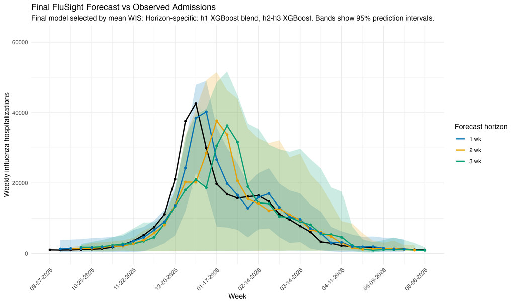

## 9 FluSight Compliance Audit

```r
read_csv(compliance_audit_csv, show_col_types = FALSE) %>%
  kable(caption = "Automated compliance checks applied before final export.")
```

Automated compliance checks applied before final export.

| check | status | detail |
| --- | --- | --- |
| canonical_column_order | OK | reference_date, target, horizon, target_end_date, location, output_type, output_type_id, value |
| date_columns_are_Date | OK | reference_date and target_end_date parsed as Date before writing |
| target_dates_equal_reference_plus_horizon | OK | validated for every row |
| full_23_quantile_ladder | OK | 0.01, 0.025, 0.05, 0.1, 0.15, 0.2, 0.25, 0.3, 0.35, 0.4, 0.45, 0.5, 0.55, 0.6, 0.65, 0.7, 0.75, 0.8, 0.85, 0.9, 0.95, 0.975, 0.99 |
| nondecreasing_quantiles | OK | validated within every reference_date/horizon |
| nonnegative_integer_values | OK | validated by integer and lower-bound checks |
| horizons_are_1_2_3 | OK | exactly 1, 2, and 3 |
| rows_per_reference_date | OK | 69 rows per reference date: 3 horizons x 23 quantiles |
| intervals_widen_with_horizon | DIAGNOSTIC | diagnostic only for selected direct/hybrid model; not a FluSight schema requirement |
| one_submission_file_per_reference_date | OK | 34 files written |
| selected_by_lowest_mean_wis | OK | Horizon-specific: h1 XGBoost blend, h2-h3 XGBoost |
| causal_post_peak_feature | OK | post_peak_decline uses peak_seen_before, then a six-week lag |

```r
read_csv(reconciliation_audit_csv, show_col_types = FALSE) %>%
  kable(caption = "Forecast reconciliation diagnostics for the selected final model.")
```

Forecast reconciliation diagnostics for the selected final model.

| check | status | detail |
| --- | --- | --- |
| nonnegative_values | OK | all forecast values are nonnegative |
| integer_values | OK | all forecast values are integer counts |
| monotone_quantiles | OK | quantiles are nondecreasing within each reference date and horizon |
| target_dates | OK | target_end_date equals reference_date + 7 * horizon |
| reasonable_horizon_median_growth | OK | 34/34 reference dates pass median-growth diagnostic |
| reasonable_horizon_width_growth | OK | 34/34 reference dates pass width-growth diagnostic |

```r
manifest <- read_csv(submission_manifest_csv, show_col_types = FALSE)
manifest %>%
  kable(caption = "Per-reference-date FluSight submission files.")
```

Per-reference-date FluSight submission files.

| reference_date | file | rows | horizons | quantiles_per_horizon |
| --- | --- | --- | --- | --- |
| 2025-09-27 | output/data/08_flusight/final_flusight_submission/2025-09-27-Carol-FluSight.csv | 69 | 123 | 23 |
| 2025-10-04 | output/data/08_flusight/final_flusight_submission/2025-10-04-Carol-FluSight.csv | 69 | 123 | 23 |
| 2025-10-11 | output/data/08_flusight/final_flusight_submission/2025-10-11-Carol-FluSight.csv | 69 | 123 | 23 |
| 2025-10-18 | output/data/08_flusight/final_flusight_submission/2025-10-18-Carol-FluSight.csv | 69 | 123 | 23 |
| 2025-10-25 | output/data/08_flusight/final_flusight_submission/2025-10-25-Carol-FluSight.csv | 69 | 123 | 23 |
| 2025-11-01 | output/data/08_flusight/final_flusight_submission/2025-11-01-Carol-FluSight.csv | 69 | 123 | 23 |
| 2025-11-08 | output/data/08_flusight/final_flusight_submission/2025-11-08-Carol-FluSight.csv | 69 | 123 | 23 |
| 2025-11-15 | output/data/08_flusight/final_flusight_submission/2025-11-15-Carol-FluSight.csv | 69 | 123 | 23 |
| 2025-11-22 | output/data/08_flusight/final_flusight_submission/2025-11-22-Carol-FluSight.csv | 69 | 123 | 23 |
| 2025-11-29 | output/data/08_flusight/final_flusight_submission/2025-11-29-Carol-FluSight.csv | 69 | 123 | 23 |
| 2025-12-06 | output/data/08_flusight/final_flusight_submission/2025-12-06-Carol-FluSight.csv | 69 | 123 | 23 |
| 2025-12-13 | output/data/08_flusight/final_flusight_submission/2025-12-13-Carol-FluSight.csv | 69 | 123 | 23 |
| 2025-12-20 | output/data/08_flusight/final_flusight_submission/2025-12-20-Carol-FluSight.csv | 69 | 123 | 23 |
| 2025-12-27 | output/data/08_flusight/final_flusight_submission/2025-12-27-Carol-FluSight.csv | 69 | 123 | 23 |
| 2026-01-03 | output/data/08_flusight/final_flusight_submission/2026-01-03-Carol-FluSight.csv | 69 | 123 | 23 |
| 2026-01-10 | output/data/08_flusight/final_flusight_submission/2026-01-10-Carol-FluSight.csv | 69 | 123 | 23 |
| 2026-01-17 | output/data/08_flusight/final_flusight_submission/2026-01-17-Carol-FluSight.csv | 69 | 123 | 23 |
| 2026-01-24 | output/data/08_flusight/final_flusight_submission/2026-01-24-Carol-FluSight.csv | 69 | 123 | 23 |
| 2026-01-31 | output/data/08_flusight/final_flusight_submission/2026-01-31-Carol-FluSight.csv | 69 | 123 | 23 |
| 2026-02-07 | output/data/08_flusight/final_flusight_submission/2026-02-07-Carol-FluSight.csv | 69 | 123 | 23 |
| 2026-02-14 | output/data/08_flusight/final_flusight_submission/2026-02-14-Carol-FluSight.csv | 69 | 123 | 23 |
| 2026-02-21 | output/data/08_flusight/final_flusight_submission/2026-02-21-Carol-FluSight.csv | 69 | 123 | 23 |
| 2026-02-28 | output/data/08_flusight/final_flusight_submission/2026-02-28-Carol-FluSight.csv | 69 | 123 | 23 |
| 2026-03-07 | output/data/08_flusight/final_flusight_submission/2026-03-07-Carol-FluSight.csv | 69 | 123 | 23 |
| 2026-03-14 | output/data/08_flusight/final_flusight_submission/2026-03-14-Carol-FluSight.csv | 69 | 123 | 23 |
| 2026-03-21 | output/data/08_flusight/final_flusight_submission/2026-03-21-Carol-FluSight.csv | 69 | 123 | 23 |
| 2026-03-28 | output/data/08_flusight/final_flusight_submission/2026-03-28-Carol-FluSight.csv | 69 | 123 | 23 |
| 2026-04-04 | output/data/08_flusight/final_flusight_submission/2026-04-04-Carol-FluSight.csv | 69 | 123 | 23 |
| 2026-04-11 | output/data/08_flusight/final_flusight_submission/2026-04-11-Carol-FluSight.csv | 69 | 123 | 23 |
| 2026-04-18 | output/data/08_flusight/final_flusight_submission/2026-04-18-Carol-FluSight.csv | 69 | 123 | 23 |
| 2026-04-25 | output/data/08_flusight/final_flusight_submission/2026-04-25-Carol-FluSight.csv | 69 | 123 | 23 |
| 2026-05-02 | output/data/08_flusight/final_flusight_submission/2026-05-02-Carol-FluSight.csv | 69 | 123 | 23 |
| 2026-05-09 | output/data/08_flusight/final_flusight_submission/2026-05-09-Carol-FluSight.csv | 69 | 123 | 23 |
| 2026-05-16 | output/data/08_flusight/final_flusight_submission/2026-05-16-Carol-FluSight.csv | 69 | 123 | 23 |

The output directory contains one validated file per reference date. Each file has 69 rows: 3 horizons times 23 quantiles.